# Estimating Non Linear Threshold for Selected Brands

We import two datasets (Bottled Water Category) that has statistical evidence for “historical price gap” (Ramlosa at Supermarket) and “both historical and competitive price gap” (Loka at Supermarket)

```r
library(dplyr) #for mutate factor
library(data.table) #turning results in table
```

```r
df_his <- read.csv("../../../../src/analysis/nonlinear_byformat/price threshold/ramlosa_super_histgap.csv")
df_his <- df_his %>% mutate(vecka=droplevels(as.factor(vecka)))
df_full <- read.csv("../../../../src/analysis/nonlinear_byformat/price threshold/loka_super_fullgap.csv")
df_full <- df_full %>% mutate(vecka=droplevels(as.factor(vecka)))
```

Model Free Evidence Between Price and Sales

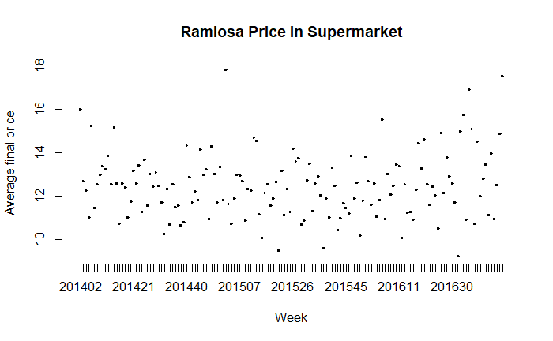

```r
plot(df_his$vecka, df_his$avgfinalprice, main = "Ramlosa Price in Supermarket", xlab = "Week", ylab = "Average final price", col="blue")
```

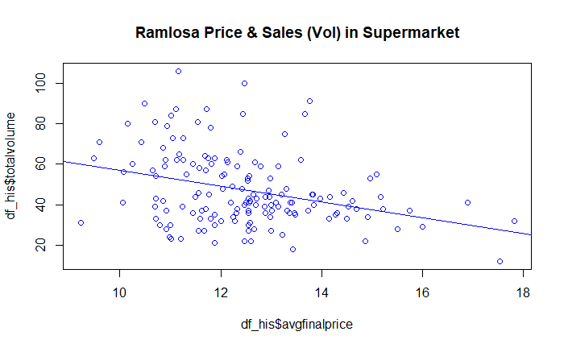

```r
plot(df_his$totalvolume ~ df_his$avgfinalprice, main = "Ramlosa Price & Sales (Vol) in Supermarket", col="blue")
abline(lm(df_his$totalvolume ~ df_his$avgfinalprice), col="blue")
```

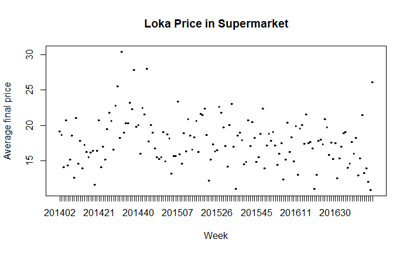

```r
plot(df_full$vecka, df_full$avgfinalprice, main = "Loka Price in Supermarket", xlab = "Week", ylab = "Average final price", col="blue")
```

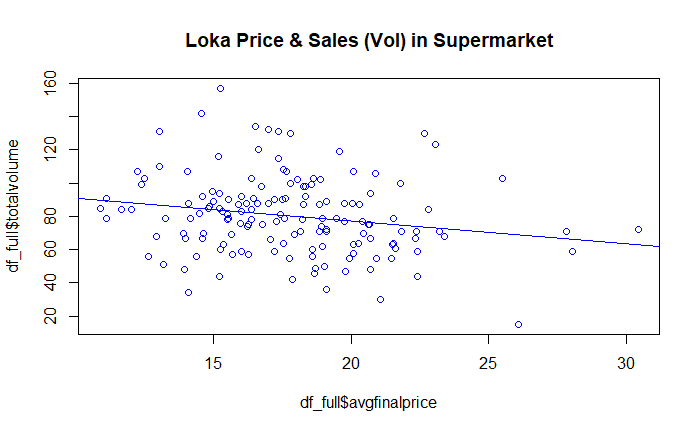

```r
plot(df_full$totalvolume ~ df_full$avgfinalprice, main = "Loka Price & Sales (Vol) in Supermarket", col="blue")
abline(lm(df_full$totalvolume ~ df_full$avgfinalprice), col="blue")
```

```r
#According to Hannes Code
make_copula <- function(x) {
        if (length(unique(x))==1) return(as.numeric(rep(NA, length(x))))
        return(ifelse(ecdf(x)(x)==1, qnorm(1-.0000001), qnorm(ecdf(x)(x))))}
#This functions transforms a variable (condition: non-normally distributed) to its copula-correction term which can be entered in model estimation. See Park and Gupta (2012, Marketing Science)

df_his$cop_logfinalprice <- make_copula(log((df_his$avgfinalprice)))
df_his$cop_logfinalprice1 <- make_copula(log((df_his$avgfinalprice1)))
df_his$cop_logavgcompfinalprice <- make_copula(log(df_his$avgcompfinalprice))

df_full$cop_logfinalprice <- make_copula(log((df_full$avgfinalprice)))
df_full$cop_logfinalprice1 <- make_copula(log((df_full$avgfinalprice1)))
df_full$cop_logavgcompfinalprice <- make_copula(log(df_full$avgcompfinalprice))
```

1. Simple Model to calculate error (correction) term:
   $$(1) ln(S_{i,t-1}) = a_{0i}+a_{1i}ln(P_{it-1})
   +a_{2i}Copulaln(P_{it-1}) + e_{it}$$

```r
lm_sim_his <- lm(log(totalvolume1) ~ log(avgfinalprice1) + cop_logfinalprice1, data = df_his)
df_his$et_hat = residuals(lm_sim_his)

lm_sim_full <- lm(log(totalvolume1) ~ log(avgfinalprice1) + cop_logfinalprice1, data = df_full)
df_full$et_hat = residuals(lm_sim_full)
```

2. Ideally we want to estimate:
   $$(2) \Delta
   ln(S_{i,t}) = \beta_{0i}+\beta_{1i}\Delta (P_{it})+\beta_{2i}\Delta
   ln(CompP_{it}) + \phi_1e_it + ...$$
   Where:

$\beta_{1i}$ for brand that has statistical evidence for “historical price gap” is
$$F(GAP) = \alpha_{0i}+
\alpha_{GH}f(HistPGap_{i,t})_G+
\alpha_{GL}f(HistPGap_{i,t})_L$$

and

$\beta_{1i}$ for brand that has statistical evidence for “both historical and competitive price gap” is
$$F(GAP) = \alpha_{0i}+
\alpha_{HG}f(HistP_{i,t})_G+ \alpha_{HL}f(HistPGap_{i,t})_L +
\alpha_{CG}f(CompPGap_{i,t})_G+
\alpha_{CL}f(CompPGap_{i,t})_L$$

To incorporate $F(GAP)$ in (2) and estimate the parameters, we need Maximum likelihood estimation

For simplicity, we will set initial value of each $\beta_ki$ based on the linear estimation (2) (i.e., $\alpha_{0i} = \beta_{1i}$)

Our challenging task is to set the initial value for $\alpha_{HG}$, $\alpha_{HL}$, $\alpha_{CG}$, $\alpha_{CL}$ which affect the curvature (slope or elasticity) of $\Delta P_{it}$